# Single-cell analysis in health liver and Hepatocellular Carcinoma

Elena Melnik

This tutorial was made as part of the course “Single-cell data analysis” from GenomicsUa (http://genomics.org.ua/2021/03/training-course-in-single-cell-biology/)

Task: To identify the contained cells from a sample of health liver and Hepatocellular Carcinoma.

# Introduction

Single-cell RNA sequencing using datasets of healthy liver cells and liver cells with hepatocarcinoma.

The first dataset describes the immune microenvironment of healthy human liver cells: namely 8444 parenchymal cells and non-parenchymal cells from fresh liver tissue of 5 human livers. Methods of differential gene expression, flow cytometry, and immunohistology were used.

Twenty populations of hepatocytes, endothelial cells, cholangiocytes, hepatic stellate cells, B cells, conventional and non-conventional T cells, NK-like cells, and individual intrahepatic distinct intrahepatic monocyte/macrophage populations have been identified.

MacParland, S.A., Liu, J.C., Ma, XZ. et al. Single cell RNA sequencing of human liver reveals distinct intrahepatic macrophage populations. Nat Commun 9, 4383 (2018). https://doi.org/10.1038/s41467-018-06318-7

Identified two populations of macrophages in the liver. Further research may provide a more detailed description and role in liver disease.

Also, not all cells are captured in a tissue section with the same frequency. Thus, it is important to consider when interpreting any scRNA-seq results. Alternatively, studies with many original samples with little variability can determine the frequency of cell populations and their sinusoidal zoning.

It is also possible to compare scRNA-seq to single nucleus RNA-seq (sNuc-seq) from frozen tissue samples to validate the single-cell profiles dissociation protocol. This is necessary for the maximum possible decrease in gene expression during dissociation to elucidate the transcriptomes of genes sensitive to decay.

Unfortunately, a complete transcriptomic map of healthy cells of all human organs has not yet been created. Only individual islets of pancreatic cells have been published until now. Further research should help in its formation.

## Although Kupffer cells (KCs) represent most macrophages in the human body, little research is related to them. This study is significant for understanding the functioning of the human immune system and should also be studied in more detail.

Since the effectiveness of treatment depends on the immune response, there is a need to describe immune cells infiltrating a tumor compared to cells of other anatomical structures.

The second dataset is devoted to the problems of the microenvironment of hepatocarcinoma, which has not been described in sufficient detail today. As a result, transcriptomes of the immune system cells, the tumor of this cell, were obtained, the samples of which were taken directly from the tumor itself near the liver, liver lymph nodes, blood, and ascites. Ascites or excessive fluid accumulation in the abdomen is associated with a negative prognosis in hepatocarcinoma. Still, the role of ascites in tumor formation and the immune response is unknown today.

Cluster LAMP3+ dendritic cells DCs can move from the tumor to the lymph node. DCs also appear to have the ability to regulate several subtypes of lymphocytes.

DCs also appear to have the ability to regulate several subtypes of lymphocytes. Tumor-associated macrophages (TAMs): SLC40A1 and GPNMB are associated with inflammation. They prevent T-cells from recognizing and destroying cancer cells.

In ascites, myeloid cells are associated with the tumor and lymphoid cells with the origin of blood. The presence of myeloid cells is usually associated with a change in survival.

Samples were taken from 16 patients who were not receiving treatment. For one patient, both 10x Genomics and SMART-seq2 methods were used for more accurate and complete analysis.

Zhang, , He, Y. et al. Landscape and dynamics of single immune cells in hepatocellular carcinoma. Cell, 179 (2019). https://doi.org/10.1016/j.cell.2019.10.003

# Single-cell data analysis

Creating samples for further analysis from datasets of healthy cells and Hepatocellular Carcinoma cells.

Downloading the necessary packages and libraries for analysis

```
## here() starts at C:/Users/user/Desktop/Single-cell analysis in healthy liver and HCC
```

```
##
## groupGOTerms:    GOBPTerm, GOMFTerm, GOCCTerm environments built.
```

```
## Attaching SeuratObject
```

Checking installed packages

```r
(.packages())
```

```
##  [1] "metap"         "SeuratObject"  "Seurat"        "forcats"
##  [5] "stringr"       "purrr"         "readr"         "tidyr"
##  [9] "tibble"        "ggplot2"       "tidyverse"     "cowplot"
## [13] "Rgraphviz"     "grid"          "topGO"         "SparseM"
## [17] "GO.db"         "AnnotationDbi" "IRanges"       "S4Vectors"
## [21] "stats4"        "Biobase"       "graph"         "BiocGenerics"
## [25] "parallel"      "ReactomeGSA"   "sctransform"   "dplyr"
## [29] "patchwork"     "here"          "stats"         "graphics"
## [33] "grDevices"     "utils"         "datasets"      "methods"
## [37] "base"
```

```r
here()
```

```
## [1] "C:/Users/user/Desktop/Single-cell analysis in healthy liver and HCC"
```

```r
data_dir_1 <- here("datasets", "hcc")
sample1_data <- Read10X(data.dir = data_dir_1)
HCC_sample <- CreateSeuratObject(counts = sample1_data, project = "HCC")

data_dir_2 <- here("datasets", "healthy")
sample2_data <- Read10X(data.dir = data_dir_2)
healthy_sample <- CreateSeuratObject(counts = sample2_data, project = "Healthy")
```

Filtering the resulting samples by the number of nucleotide repeats and by the percentage of mitochondrial DNA. Healthy liver cells have more mitochondrial DNA due to the presence of various non-immune cells.

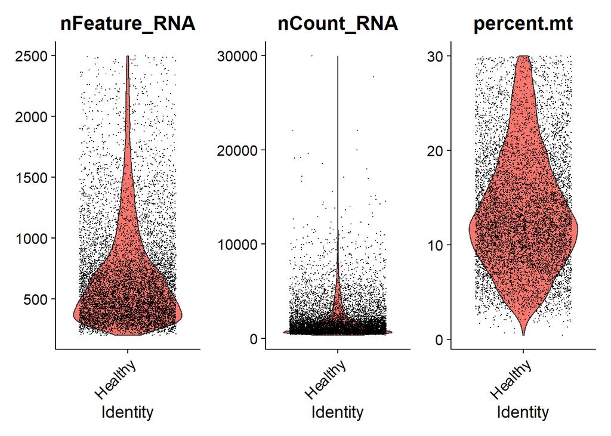

```r
#healthy_mt
healthy_sample[["percent.mt"]] <-
  PercentageFeatureSet(healthy_sample, pattern = "^MT-")
VlnPlot(healthy_sample, features =
          c("nFeature_RNA", "nCount_RNA", "percent.mt"), ncol = 3)
```

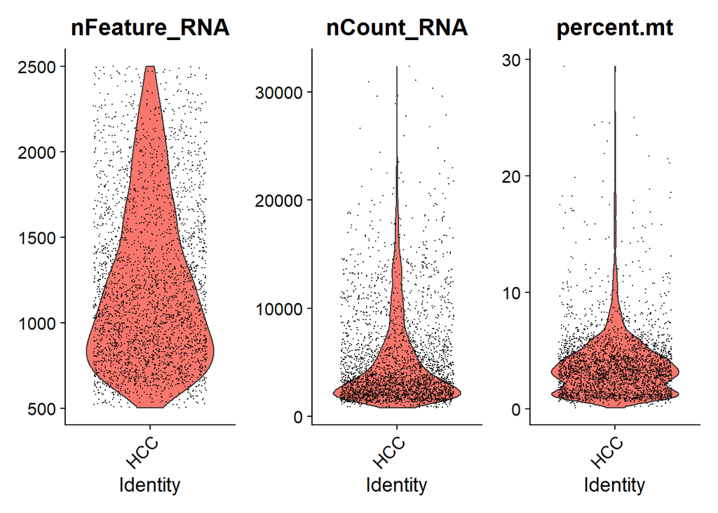

```r
#HCC_mt
HCC_sample[["percent.mt"]] <-
  PercentageFeatureSet(HCC_sample, pattern = "^MT-")
VlnPlot(HCC_sample, features =
          c("nFeature_RNA", "nCount_RNA", "percent.mt"), ncol = 3)
```

```r
#filter_out
healthy_sample <- subset(healthy_sample, subset = nFeature_RNA > 200
                         & nFeature_RNA < 2500 & percent.mt < 30)
HCC_sample <- subset(HCC_sample, subset = nFeature_RNA > 200
                         & nFeature_RNA < 2500 & percent.mt < 30)
```

Convert absolute values to logarithmic values. Scaling the data by dividing the number of nucleotide repeats in each cell by the total. Multiplying by a certain number (10,000 for our normalization). Transformation into a natural logarithm.

```r
datasets.list <- list(healthy_sample, HCC_sample)

datasets.list <- lapply(X = datasets.list, FUN = function(x) {
    x <- NormalizeData(x)
    x <- FindVariableFeatures(x, selection.method = "vst", nfeatures = 2000)
})

features <- SelectIntegrationFeatures(object.list = datasets.list)

datasets.anchors <- FindIntegrationAnchors(object.list = datasets.list, anchor.features = features)
```

```
## Scaling features for provided objects
```

```
## Finding all pairwise anchors
```

```
## Running CCA
```

```
## Merging objects
```

```
## Finding neighborhoods
```

```
## Finding anchors
```

```
##  Found 8569 anchors
```

```
## Filtering anchors
```

```
##  Retained 4930 anchors
```

```r
datasets.integrated <- IntegrateData(anchorset = datasets.anchors)
```

```
## Merging dataset 2 into 1
```

```
## Extracting anchors for merged samples
```

```
## Finding integration vectors
```

```
## Finding integration vector weights
```

```
## Integrating data
```

Having 2 arrays of metadata. Dimension reduction based on principal component analysis Finding 18 clusters

```r
#lognormalize
datasets.integrated <- ScaleData(datasets.integrated, verbose = FALSE)
datasets.integrated <- RunPCA(datasets.integrated, npcs = 30, verbose = FALSE)
datasets.integrated <- RunUMAP(datasets.integrated, reduction = "pca", dims = 1:30)
datasets.integrated <- FindNeighbors(datasets.integrated, reduction = "pca", dims = 1:30)
datasets.integrated <- FindClusters(datasets.integrated, resolution = 0.5)
```

```
## Modularity Optimizer version 1.3.0 by Ludo Waltman and Nees Jan van Eck
##
## Number of nodes: 11989
## Number of edges: 489747
##
## Running Louvain algorithm...
## Maximum modularity in 10 random starts: 0.9298
## Number of communities: 18
## Elapsed time: 1 seconds
```

Creation of 2 plots in 2D (in-built Seurat function - DimPlot). The first plot is grouped by original ID (HCC or Healthy). The second graph shows the number of clusters and their proximity to marker genes. It can be concluded, according to the graph, that different types of cells are expressed in different clinical conditions.

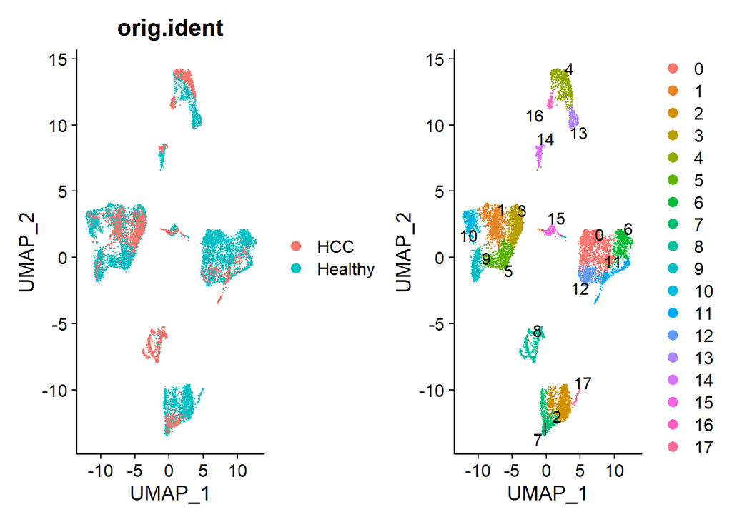

```r
p1 <- DimPlot(datasets.integrated, reduction = "umap", group.by = "orig.ident")
p2 <- DimPlot(datasets.integrated, reduction = "umap", label = TRUE, repel = TRUE)
p1 + p2
```

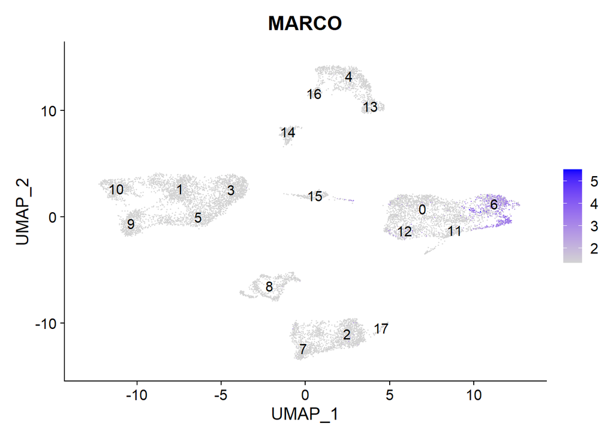

```r
DefaultAssay(datasets.integrated) <- "RNA"
#features <- c("CD20", "PD-L1", "CD19", "CD5", "CD43", "IRF4", "IL9",
#               "IL10", "CCR6", "KLRB1", "C1QA", "PPARD",
#              "CLEC4G", "MARCO")
features <- c("MARCO")
FeaturePlot(datasets.integrated, features = features, min.cutoff = "q9", label = TRUE)
```

```r
#RidgePlot(datasets.integrated, features = features, ncol = 2)
#VlnPlot(datasets.integrated, features = features, split.by = "orig.ident")
#DotPlot(datasets.integrated, features = features) + RotatedAxis()
#DoHeatmap(subset(datasets.integrated, downsample = 100), features = features, size = 3)
```

Сompiling the search results for specific genes in clusters as a table. Searching for a description of each gene using public databases Looking for data on the expression of this gene in the liver.

```r
#library(AnnotationHub)
#library(ensembldb)
#library(multtest)
#library(metap)
#BiocManager::install('limma')
#library('limma')

# Connect to AnnotationHub
#ah <- AnnotationHub()

# Access the Ensembl database for organism
#ahDb <- query(ah,
#              pattern = c("Homo sapiens", "EnsDb"),
#ignore.case = TRUE)

# Acquire the latest annotation files
#id <- ahDb %>%
#        mcols() %>%
#        rownames() %>%
#        tail(n = 1)

# Download the appropriate Ensembldb database
#edb <- ah[[id]]

# Extract gene-level information from database
#annotations <- genes(edb,
#                    return.type = "data.frame")

# Select annotations of interest
#annotations <- annotations %>%
#        dplyr::select(gene_id, gene_name, seq_name, gene_biotype, #description)

#DefaultAssay(datasets.integrated) <-"RNA"
#get_conserved <- function(cluster){
#        FindConservedMarkers(datasets.integrated,
#                             ident.1 = cluster,
#                             grouping.var = "orig.ident",
#                             only.pos = TRUE) %>%
#                rownames_to_column(var = "gene") %>%
#                cbind(cluster_id = cluster, .)
#}

# map and receive dataframe
#conserved_markers <- FindAllMarkers(datasets.integrated, #min.cells.group = 0)
#gene_descriptions <- unique(annotations[, c("gene_name", #"description")])

#ann_conserved_markers <- left_join(x = conserved_markers,
#                                   y = gene_descriptions,
#                                   by = c("gene" = "gene_name"))
#write.csv(ann_conserved_markers,"ann_conserved_markers.csv")
```

Renaming of groups of clusters according to identified cells

```r
datasets.integrated <- RenameIdents(datasets.integrated, '0' = 'Kupffer Cells S100A8+ LYZ+')
datasets.integrated <- RenameIdents(datasets.integrated, '2' = 'T-Cells CCL5 GZMH')
datasets.integrated <- RenameIdents(datasets.integrated, '3' = 'T-Cells IL32+ CD3D+')
datasets.integrated <- RenameIdents(datasets.integrated, '4' = 'B-cells')
datasets.integrated <- RenameIdents(datasets.integrated, '6' = 'Kupffer Cells C1QB+')
datasets.integrated <- RenameIdents(datasets.integrated, '8' = 'Kupffer Cells S100A9+')
datasets.integrated <- RenameIdents(datasets.integrated, '11' = 'Neutrophils')
datasets.integrated <- RenameIdents(datasets.integrated, '17' = 'Ito cells')
```

Creation of a table of the number of cells for each cluster We have identified the following cells in the dataset. 3 types of Kupffer cells (663, 764, 1658), 2 types of T-cells (1040, 1183), B-cells (840), Neutrophils (480), and ito-cells (50).

```r
cell.num <- table(Idents(datasets.integrated))
view(cell.num)
```

Difference between one cell type and another. Determination of metabolic pathways of selected cells in the reactome database Selected Kupffer Cells S100A8+ LYZ+ are clearly manifested in Oleoyl-phe metabolism. Extracellular PM20D1 (N-fatty-acyl-amino acid synthase/hydrolase PM20D1) catalyzes the reversible condensation of L-phenylalanine (L-phe) and oleate ((9Z)-octadecenoate) to form oleoyl-phe (N-(9Z-octadecenoyl)-L-phenylalanine) and water.

S100A8 Gene - S100 Calcium Binding Protein A8

And Kupffer Cells S100A9 + take part in the ATP sensitive Potassium channels. S100A9 - S100 Calcium Binding Protein A9

The proteins encoded by these genes are members of the S100 family of proteins containing 2 EF-hand calcium-binding motifs. S100 proteins are localized in the cytoplasm and/or nucleus of a wide range of cells, and involved in the regulation of a number of cellular processes such as cell cycle progression and differentiation. S100 genes include at least 13 members which are located as a cluster on chromosome 1q21. This protein may function in the inhibition of casein kinase and as a cytokine. Altered expression of this protein is associated with the disease cystic fibrosis. Multiple transcript variants encoding different isoforms have been found for this gene.

```r
#Reference: https://bioconductor.org/packages/release/bioc/vignettes/ReactomeGSA/inst/doc/analysing-scRNAseq.html
my_awesome_cells <- subset(datasets.integrated, idents = c("Kupffer Cells S100A8+ LYZ+", "Kupffer Cells S100A9+"))
gsva_result <- analyse_sc_clusters(my_awesome_cells, verbose = TRUE)
```

```
## Calculating average cluster expression...
```

```
## Converting expression data to string... (This may take a moment)
```

```
## Conversion complete
```

```
## Submitting request to Reactome API...
```

```
## Compressing request data...
```

```
## Reactome Analysis submitted succesfully
```

```
## Converting dataset Seurat...
```

```
## Mapping identifiers...
```

```
## Performing gene set analysis using ssGSEA
```

```
## Analysing dataset 'Seurat' using ssGSEA
```

```
## Retrieving result...
```

```r
pathway_expression <- pathways(gsva_result)

colnames(pathway_expression) <- gsub("\\.Seurat", "", colnames(pathway_expression))

pathway_expression[1:3,]
```

```
##                                          Name Kupffer_Cells_S100A8_LYZ
## R-HSA-1059683         Interleukin-6 signaling                0.1452140
## R-HSA-109606  Intrinsic Pathway for Apoptosis                0.1119439
## R-HSA-109703              PKB-mediated events                0.1070255
##               Kupffer_Cells_S100A9
## R-HSA-1059683            0.1296429
## R-HSA-109606             0.1164850
## R-HSA-109703             0.1161294
```

```r
max_difference <- do.call(rbind, apply(pathway_expression, 1, function(row) {
    values <- as.numeric(row[2:length(row)])
    return(data.frame(name = row[1], min = min(values), max = max(values)))
}))
max_difference$diff <- max_difference$max - max_difference$min
# sort based on the difference
max_difference <- max_difference[order(max_difference$diff, decreasing = T), ]

head(max_difference)
```

```
##                                                               name        min
## R-HSA-1296025                     ATP sensitive Potassium channels -0.2989160
## R-HSA-1299361 TWIK-related alkaline pH activated K+ channel (TALK) -0.4717615
## R-HSA-9673163                                Oleoyl-phe metabolism -0.2452607
## R-HSA-140180                                         COX reactions -0.4948657
## R-HSA-561048                               Organic anion transport -0.4209123
## R-HSA-964975         Vitamins B6 activation to pyridoxal phosphate -0.2030988
##                        max      diff
## R-HSA-1296025  0.369399429 0.6683154
## R-HSA-1299361  0.188092417 0.6598539
## R-HSA-9673163  0.408372828 0.6536335
## R-HSA-140180  -0.003653238 0.4912125
## R-HSA-561048   0.051737757 0.4726501
## R-HSA-964975   0.257546257 0.4606451
```

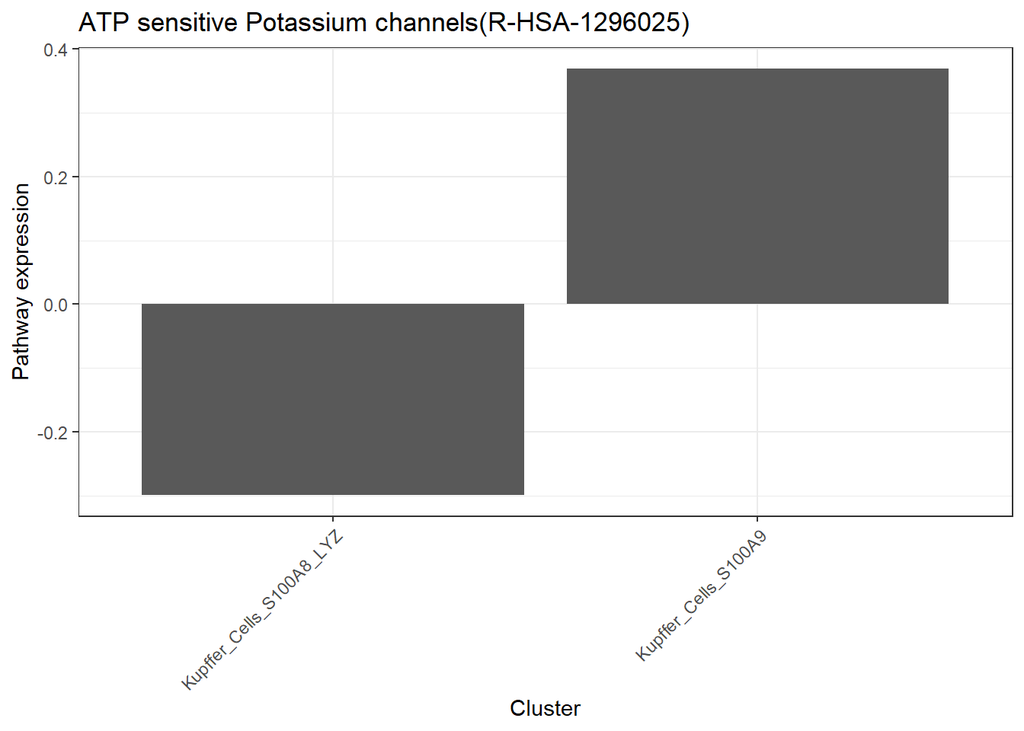

```r
plot_gsva_pathway(gsva_result, pathway_id = rownames(max_difference)[1])
```

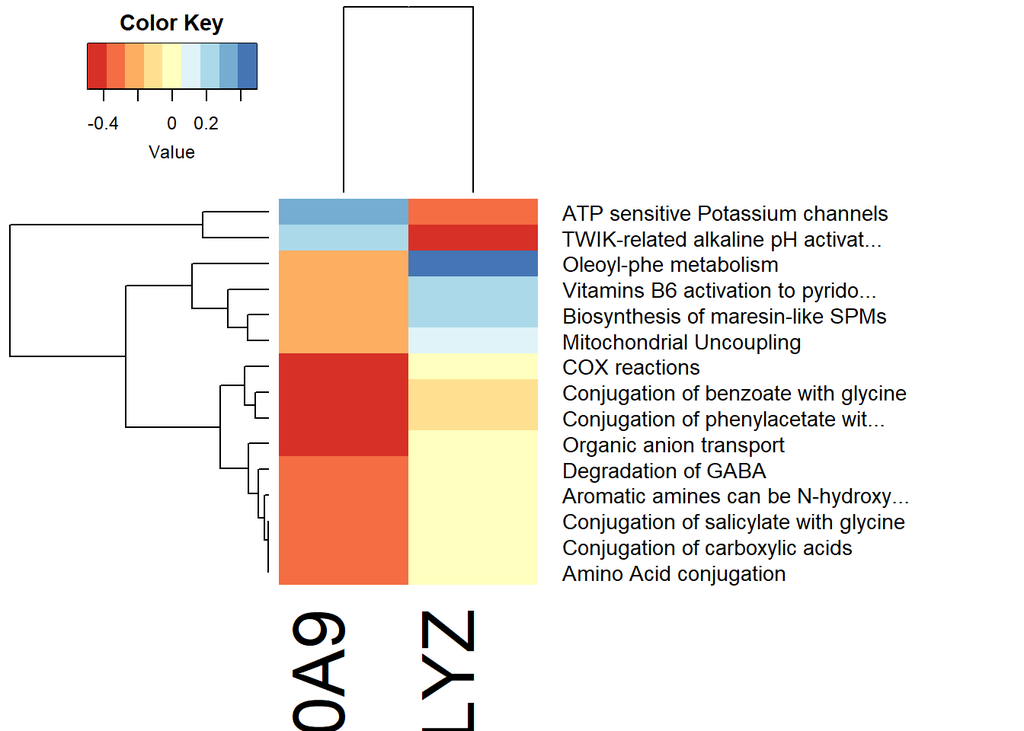

```r
plot_gsva_heatmap(gsva_result, max_pathways = 15, margins = c(6,20))
```

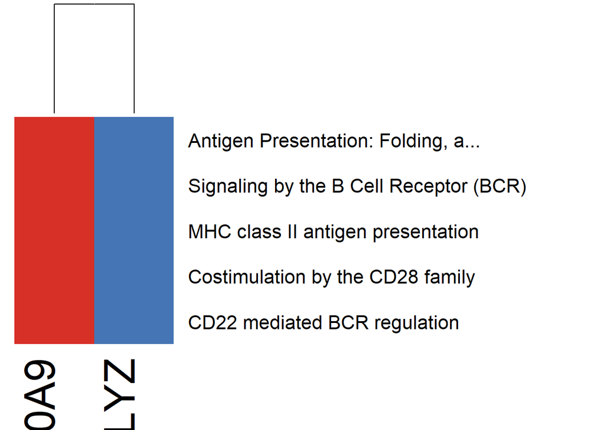

```r
# limit to selected B cell related pathways
relevant_pathways <- c("R-HSA-983170", "R-HSA-388841", "R-HSA-2132295", "R-HSA-983705", "R-HSA-5690714")
plot_gsva_heatmap(gsva_result,
                  pathway_ids = relevant_pathways, # limit to these pathways
                  margins = c(6,30), # adapt the figure margins in heatmap.2
                  dendrogram = "col", # only plot column dendrogram
                  scale = "row", # scale for each pathway
                  key = FALSE, # don't display the color key
                  lwid=c(0.1,4)) # remove the white space on the left
```

# Discussion